# Diari 6 - Inferència i conclusions

JHJ

20/12/2024

## Qüestions abordades

*Escriviu les qüestions que heu decidit abordar.*

1. Quines conclusions podem extreure de la resta de diaris?

## Comentaris

*Qualsevol cosa que vulgueu afegir sobre les qüestions.*

- Al diari anterior, vam veure que les nostres dades semblen més homoscedastiques aplicant una transformació logarítmica, i també vam veure que les nostres dades intenten ajustar-se a una skew normal amb $\alpha \pm 4$ sense molt d’èxit.

## Variables relacionades

*Quines variables del vostre conjunt de dades, o d’altres, us sembla que caldrà considerar?*

- log(Temps d’execució de cada algoritme)
- log(mida del vector)

## Resultats

Primer, recordem la transformació logarítmica, i que gràcies a això no podem assumir homoscedasticitat, però almenys estem més a prop de poder assumir-la.

```r
simulacions.res = mutate(simulacions,
                         l_mida = log(mida),
                         l_bubblesort = log(bubblesort),
                         l_quicksort = log(quicksort),
                         l_mergesort = log(mergesort))
```

I tornem a ajustar els models ajustats en diaris anteriors.

```r
# models per explicar el temps de cada algoritme amb la mida del vector (vectors desordenats)
mods = list(
  lm.bubblesort = lm(bubblesort~mida+I(mida^2), data = simulacions.res),
  lm.quicksort = lm(quicksort~mida+I(mida*log(mida)), data = simulacions.res),
  lm.mergesort = lm(mergesort~mida+I(mida*log(mida)), data = simulacions.res)
)
# el mateix, però amb vectors ordenats
mods.ord = list(
  lm.bubblesort = lm(ord.bubblesort~mida+I(mida^2), data = simulacions),
  lm.quicksort = lm(ord.quicksort~mida+I(mida^2), data = simulacions),
  lm.mergesort = lm(ord.mergesort~mida+I(mida*log(mida)), data = simulacions)
)
# el mateix, però explicant el logaritme dels temps de cada algoritme
mods.log = list(
  lm.bubblesort = lm(l_bubblesort~l_mida+I(l_mida^2), data = simulacions.res),
  lm.quicksort = lm(l_quicksort~l_mida+I(l_mida*log(l_mida)), data = simulacions.res),
  lm.mergesort = lm(l_mergesort~l_mida+I(l_mida*log(l_mida)), data = simulacions.res)
)
```

### Descriptiva de les dades

A continuació recordem que vam fer una descriptiva de les dades. Començant per la mida, comparant-la amb log(mida) fent servir la funció `summary()`.

```r
summary(select(simulacions.res, mida, l_mida))
```

```
##       mida            l_mida
##  Min.   :  10.0   Min.   :2.303
##  1st Qu.: 257.5   1st Qu.:5.551
##  Median : 505.0   Median :6.225
##  Mean   : 505.0   Mean   :5.940
##  3rd Qu.: 752.5   3rd Qu.:6.623
##  Max.   :1000.0   Max.   :6.908
```

I el mateix però amb els temps. Però en aquest cas, comparem els temps **amb vectors desordenats**, els temps **amb vectors ordenats**, i el log(temps).

```r
summary(select(simulacions.res, bubblesort, ord.bubblesort, l_bubblesort, quicksort, ord.quicksort, l_quicksort, mergesort, ord.mergesort, l_mergesort))
```

```
##    bubblesort        ord.bubblesort       l_bubblesort       quicksort
##  Min.   :0.0000007   Min.   :0.0000004   Min.   :-14.172   Min.   :1.000e-07
##  1st Qu.:0.0004002   1st Qu.:0.0002319   1st Qu.: -7.823   1st Qu.:8.000e-06
##  Median :0.0015674   Median :0.0008848   Median : -6.458   Median :1.750e-05
##  Mean   :0.0020816   Mean   :0.0011761   Mean   : -7.030   Mean   :1.826e-05
##  3rd Qu.:0.0035004   3rd Qu.:0.0019674   3rd Qu.: -5.655   3rd Qu.:2.770e-05
##  Max.   :0.0084499   Max.   :0.0049847   Max.   : -4.774   Max.   :1.226e-04
##  ord.quicksort        l_quicksort        mergesort         ord.mergesort
##  Min.   :0.0000001   Min.   :-16.118   Min.   :8.000e-07   Min.   :8.000e-07
##  1st Qu.:0.0000242   1st Qu.:-11.736   1st Qu.:2.480e-05   1st Qu.:1.888e-05
##  Median :0.0000916   Median :-10.953   Median :5.220e-05   Median :3.655e-05
##  Mean   :0.0001210   Mean   :-11.281   Mean   :5.362e-05   Mean   :3.752e-05
##  3rd Qu.:0.0002033   3rd Qu.:-10.494   3rd Qu.:8.110e-05   3rd Qu.:5.630e-05
##  Max.   :0.0009996   Max.   : -9.007   Max.   :2.457e-04   Max.   :1.931e-04
##   l_mergesort
##  Min.   :-14.039
##  1st Qu.:-10.605
##  Median : -9.860
##  Mean   :-10.148
##  3rd Qu.: -9.420
##  Max.   : -8.311
```

En diaris anteriors també ens vam Centrar en la mitjana dels temps de la mostra *en general*, és a dir, sense aplicar cap transformació sobre els temps.

**Amb vectors desordenats.**

```r
summarise(simulacions.res,
          bubblesort = mean(bubblesort),
          quicksort = mean(quicksort),
          mergesort = mean(mergesort))
```

```
## # A tibble: 1 × 3
##   bubblesort quicksort mergesort
##        <dbl>     <dbl>     <dbl>
## 1    0.00208 0.0000183 0.0000536
```

```r
summarise(filter(simulacions, mida == 50),
          bubblesort = mean(ord.bubblesort),
          quicksort = mean(ord.quicksort),
          mergesort = mean(ord.mergesort))
```

```
## # A tibble: 1 × 3
##   bubblesort  quicksort  mergesort
##        <dbl>      <dbl>      <dbl>
## 1 0.00000912 0.00000121 0.00000397
```

Veient-lo gràficament, vam veure com es comporta cada algoritme amb els dos tipus de vectors, ordenats i desordenats, a més de la forma que tenen els temps en relació amb la mida.

### BubbleSort *desordenat*

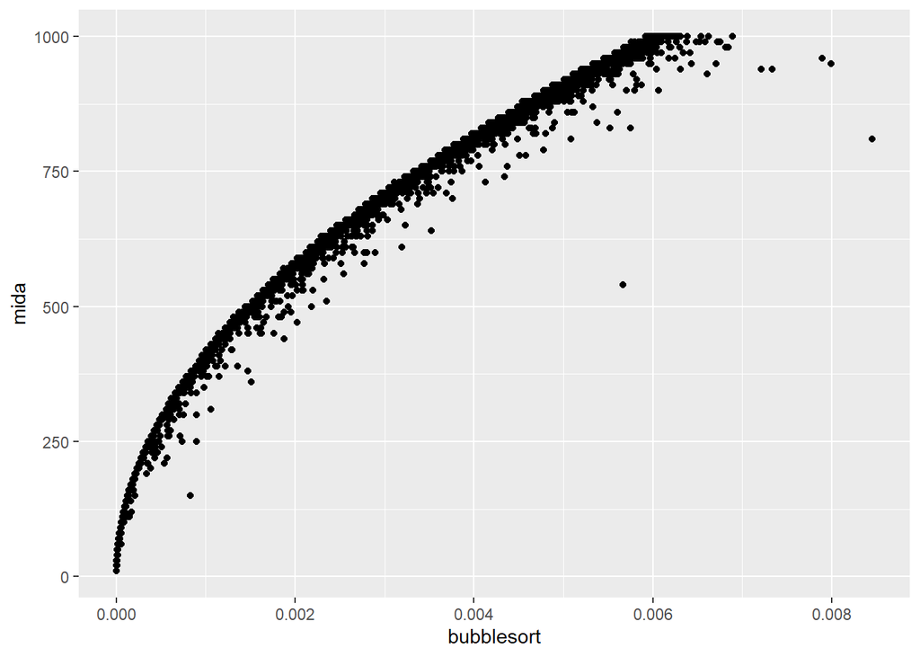

```r
ggplot(data = simulacions) +
  geom_point(aes(y = mida, x = bubblesort))
```

### QuickSort *desordenat*

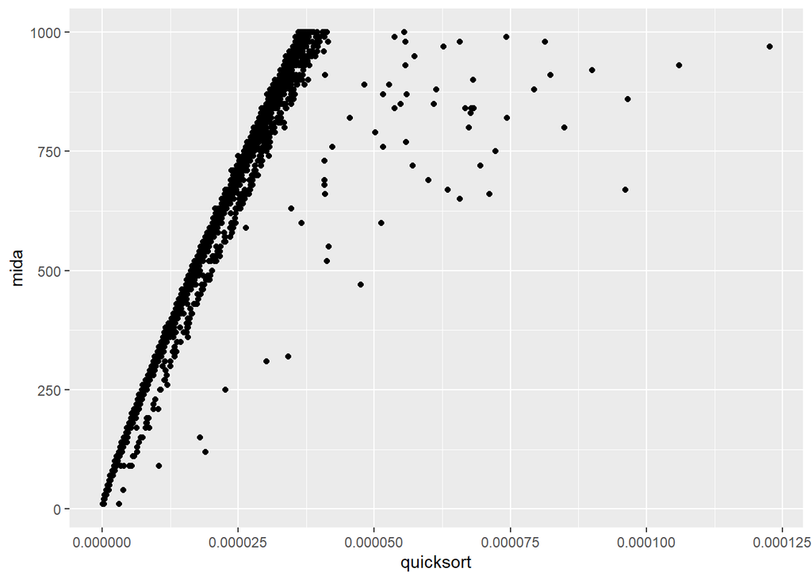

```r
ggplot(data = simulacions) +
  geom_point(aes(y = mida, x = quicksort))
```

### MergeSort *desordenat*

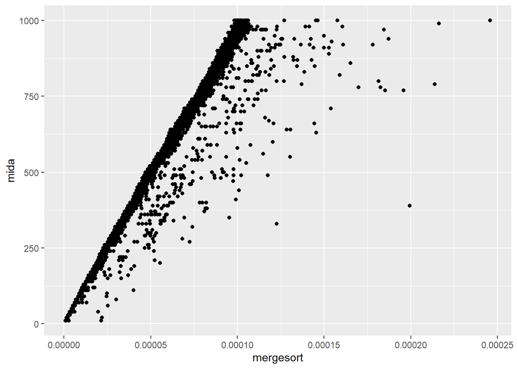

```r
ggplot(data = simulacions) +
  geom_point(aes(y = mida, x = mergesort))
```

### BubbleSort *ordenat*

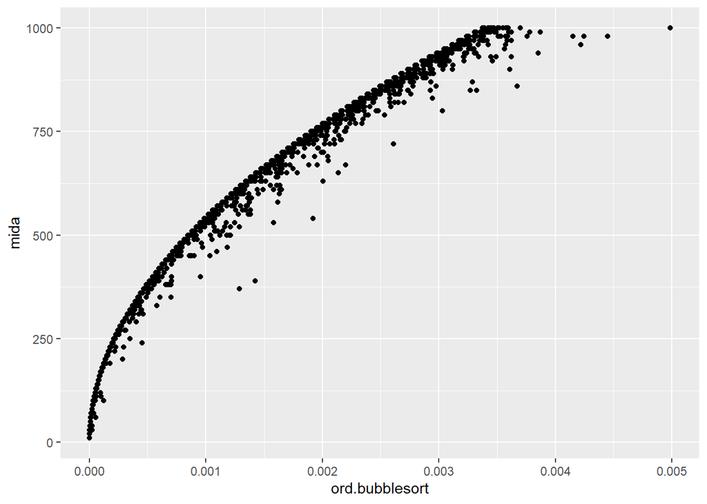

```r
ggplot(data = simulacions) +
  geom_point(aes(y = mida, x = ord.bubblesort))
```

### QuickSort *ordenat*

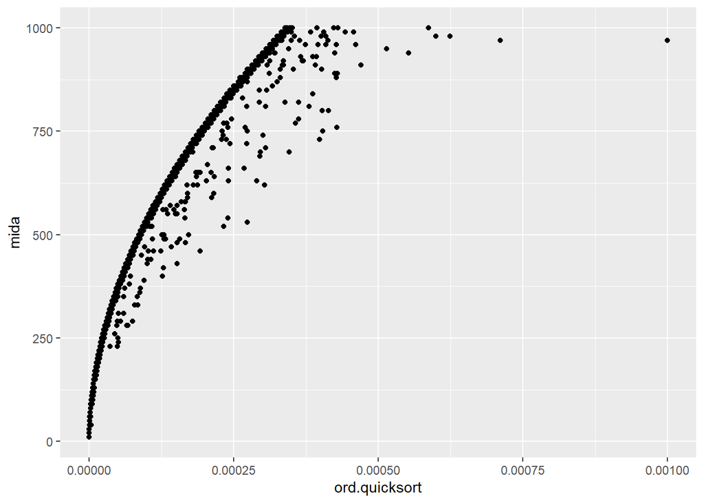

```r
ggplot(data = simulacions) +
  geom_point(aes(y = mida, x = ord.quicksort))
```

### MergeSort *ordenat*

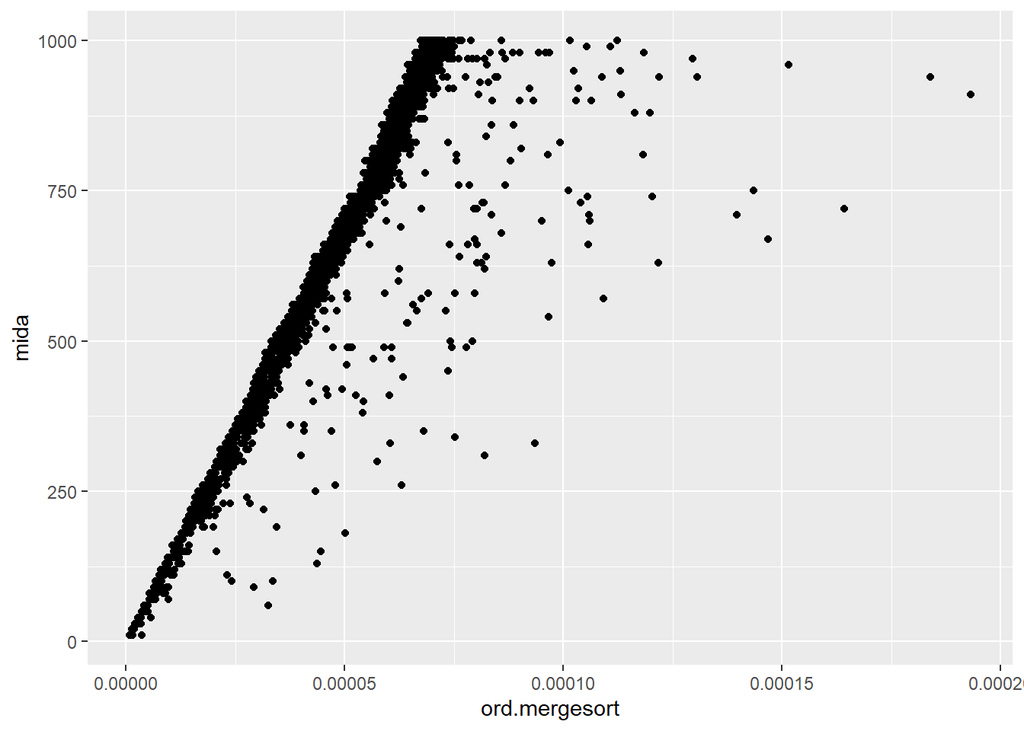

```r
ggplot(data = simulacions) +
  geom_point(aes(y = mida, x = ord.mergesort))
```

I vam veure que bubblesort i mergesort mantenen la forma, és a dir, bubblesort continua sent $O(n^2)$ i mergesort continua sent $O(n \cdot log(n))$, mentre que el quicksort amb vectors ordenats es comporta semblant al bubblesort ($O(n^2)$), amb vectors desordenats es comporta com el mergesort ($O(O(n \cdot log(n)))$), però una mica millor. Aixó té relació amb l’explicat a altres assignatures de programació: $MTP_{1 \lor 2} \lor EDA$.

En l’últim diari també vam comentar que els algoritmes que tenen una implementació recursiva, són els que també semblaven més homocedastics, **tot i no ser-ho**, i això deiem que podia ser pel fet que quicksort i mergesort s’implementen recursivament perquè la seva implementació indica que són algoritmes de divideix i venç. També vam dir que el quicksort era més senzill que el mergesort, i el mergesort no era tan senzill, però era més estable.

### Descriptiva dels residus

Un cop hem descrit les dades, podem descriure els errors dels models ajustats, **només agafarem el model que ajusta el logaritme dels temps**, ja que en diaris anterior vam veure que amb el logaritme els residus semblen és homoscedastics.

```r
summary(residuals(mods.log$lm.bubblesort))
```

```
##      Min.   1st Qu.    Median      Mean   3rd Qu.      Max.
## -0.142026 -0.026654 -0.012652  0.000000  0.005231  1.814024
```

```r
summary(residuals(mods.log$lm.quicksort))
```

```
##       Min.    1st Qu.     Median       Mean    3rd Qu.       Max.
## -0.5868812 -0.0334938 -0.0177039  0.0000000  0.0005625  2.8471060
```

```r
summary(residuals(mods.log$lm.mergesort))
```

```
##      Min.   1st Qu.    Median      Mean   3rd Qu.      Max.
## -0.162988 -0.054689 -0.033426  0.000000 -0.005892  3.124302
```

Hem descrit els residus, falta veure com varien, però això és millor visualitzar-ho amb una gràfica.

#### BubbleSort

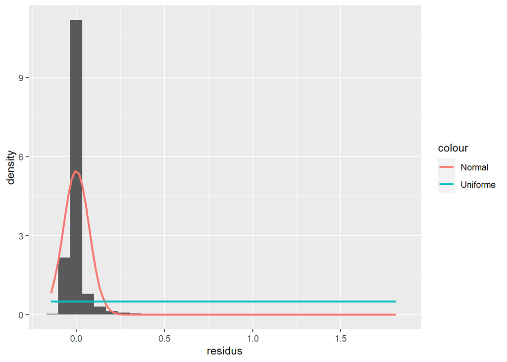

```r
histograma(mods.log$lm.bubblesort)
```

#### QuickSort

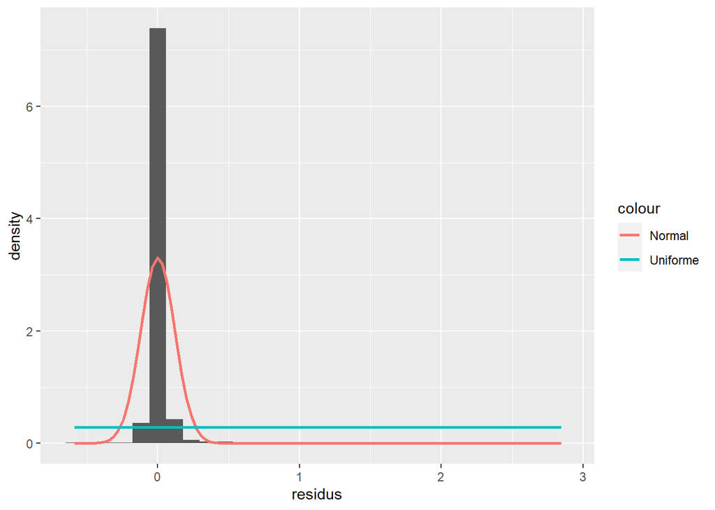

```r
histograma(mods.log$lm.quicksort)
```

#### MergeSort

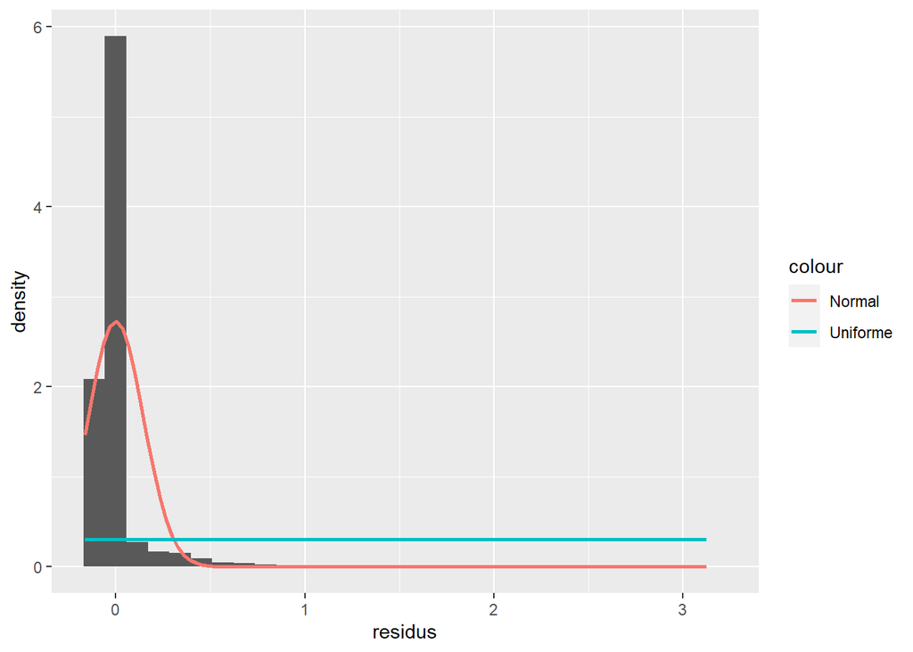

```r
histograma(mods.log$lm.mergesort)
```

A partir d’aquí ens vam centrar en estudiar la forma que tenen els errors, i vam dir que els residus semblaven seguir una normal amb **mitjana a prop del 0**.

### Hipòtesi plantejada

La nostra hipòtesi plantejada, era si hi havia una relació entre els errors dels models i la mida del vector, i quina era la forma d’aquests errors, considerant només amb **vectors desordenats**.

Per respondre a la nostra hipòtesi vam obtenir uns intervals de confiança, i entre aquest interval vam veure que els residus semblaven més normals, però en realitat només el bubblesort ho era. Per tal d’aconseguir un interval de confiança de la mitjana, en el que puguem dir si un algoritme segueix una certa distribució, o no. Com que la nostra mostra és bastant gran, llavors segons el teorema del límit central podem expressar la mitjana com.

$$\overline{X} \approx N(\mu, \frac{\sigma}{\sqrt{n}})$$

```r
aux = data.frame(
  bubblesort = tibble(
    mu = mean(residuals(mods$lm.bubblesort)),
    sigma = sd(residuals(mods$lm.bubblesort)),
    sqrt.n = sqrt(length(residuals(mods$lm.bubblesort)))),
  quicksort = tibble(
    mu = mean(residuals(mods$lm.quicksort)),
    sigma = sd(residuals(mods$lm.quicksort)),
    sqrt.n = sqrt(length(residuals(mods$lm.quicksort)))),
  mergesort = tibble(
    mu = mean(residuals(mods$lm.mergesort)),
    sigma = sd(residuals(mods$lm.mergesort)),
    sqrt.n = sqrt(length(residuals(mods$lm.mergesort))))
)

tibble(
  bubblesort = c(qnorm(.025, mean = aux$bubblesort.mu, sd = aux$bubblesort.sigma/aux$bubblesort.sqrt.n), qnorm(.975, mean = aux$bubblesort.mu, sd = aux$bubblesort.sigma/aux$bubblesort.sqrt.n)),
  quicksort = c(qnorm(.025, mean = aux$quicksort.mu, sd = aux$quicksort.sigma/aux$quicksort.sqrt.n), qnorm(.975, mean = aux$quicksort.mu, sd = aux$quicksort.sigma/aux$quicksort.sqrt.n)),
  mergesort = c(qnorm(.025, mean = aux$mergesort.mu, sd = aux$mergesort.sigma/aux$mergesort.sqrt.n), qnorm(.975, mean = aux$mergesort.mu, sd = aux$mergesort.sigma/aux$mergesort.sqrt.n))
)
```

```
## # A tibble: 2 × 3
##    bubblesort    quicksort    mergesort
##         <dbl>        <dbl>        <dbl>
## 1 -0.00000438 -0.000000108 -0.000000263
## 2  0.00000438  0.000000108  0.000000263
```

```r
int = tibble(
  bubblesort = confidence.intervals(residuals(mods$lm.bubblesort)),
  quicksort = confidence.intervals(residuals(mods$lm.quicksort)),
  mergesort = confidence.intervals(residuals(mods$lm.mergesort))
)
int
```

```
## # A tibble: 2 × 3
##    bubblesort    quicksort    mergesort
##         <dbl>        <dbl>        <dbl>
## 1 -0.00000425 -0.000000105 -0.000000256
## 2  0.00000469  0.000000113  0.000000265
```

I podem tornar a visualitzar l’histograma com.

#### BubbleSort *desordenat*

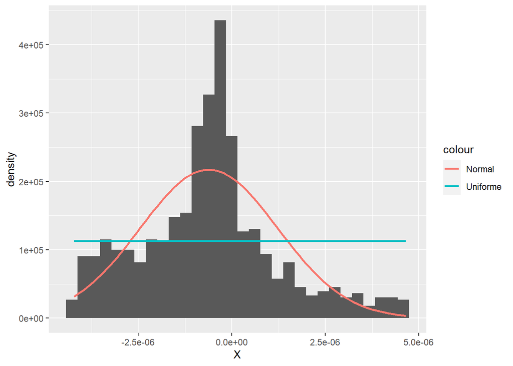

```r
histograma2(residuals(mods$lm.bubblesort)[between(residuals(mods$lm.bubblesort), int$bubblesort[1], int$bubblesort[2])])
```

#### QuickSort *desordenat*

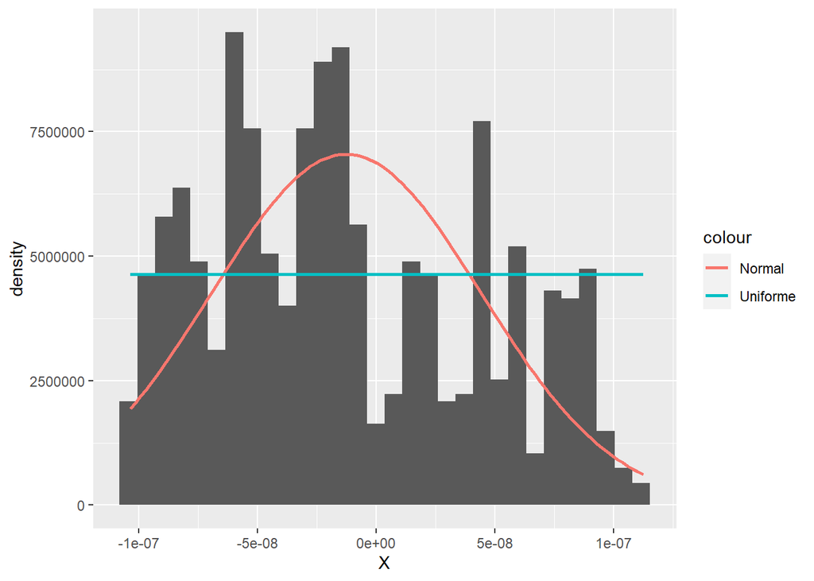

```r
histograma2(residuals(mods$lm.quicksort)[between(residuals(mods$lm.quicksort), int$quicksort[1], int$quicksort[2])])
```

#### MergeSort *desordenat*

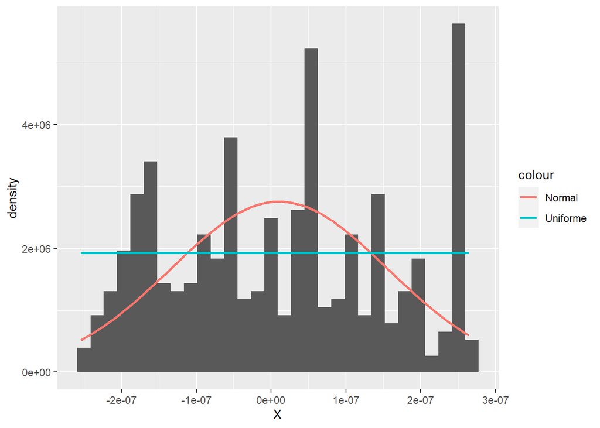

```r
histograma2(residuals(mods$lm.mergesort)[between(residuals(mods$lm.mergesort), int$mergesort[1], int$mergesort[2])])
```

I veiem que els algoritmes que són $n \cdot log(n)$, no segueixen tant la normal com el bubblesort que és $n^2$, això és perquè en realitat els residus de bubblesort si que segueixen una normal, mentre els del quicksort i el mergesort segueixen més el logaritme que una normal.

Si construïm un interval de confiança fent servir els errors del model que ajusta el logaritme dels temps, és a dir `mods.log`, tots els algoritmes seguirien el logaritme.

Això que hem dit de paraula també ho vam contrastar amb el `shapiro.test()` com.

```r
int = tibble(
  bubblesort = confidence.intervals(simulacions.res$bubblesort),
  quicksort = confidence.intervals(simulacions.res$quicksort),
  mergesort = confidence.intervals(simulacions.res$mergesort)
)
mostres = list(
  bubblesort = simulacions.res$bubblesort[between(simulacions.res$bubblesort, int$bubblesort[1], int$bubblesort[2])],
  quicksort = simulacions.res$quicksort[between(simulacions.res$quicksort, int$quicksort[1], int$quicksort[2])],
  mergesort = simulacions.res$mergesort[between(simulacions.res$mergesort, int$mergesort[1], int$mergesort[2])]
)
```

```r
shapiro.test(mostres$bubblesort)
```

```
##
##  Shapiro-Wilk normality test
##
## data:  mostres$bubblesort
## W = 0.96598, p-value = 0.07072
```

```r
shapiro.test(mostres$quicksort)
```

```
##
##  Shapiro-Wilk normality test
##
## data:  mostres$quicksort
## W = 0.91695, p-value = 7.581e-05
```

```r
shapiro.test(mostres$mergesort)
```

```
##
##  Shapiro-Wilk normality test
##
## data:  mostres$mergesort
## W = 0.94675, p-value = 0.004542
```

I veiem que l’únic que segueix una normal és el bubblesort. Per això vam dir que els intervals de confiança no ens aportaven res de nou, i vam decidir no fer-los servir, i a l’últim diari és quan vam treballar amb el logaritme dels temps, per veure si segueixen una normal, és a dir, si donem resposta al següent contrast:

$$H0: \text{Els residus són normals} \\
H1: \text{Els residus no són normals}$$

```r
shapiro.test(residuals(mods.log$lm.bubblesort))
```

```
##
##  Shapiro-Wilk normality test
##
## data:  residuals(mods.log$lm.bubblesort)
## W = 0.46104, p-value < 2.2e-16
```

```r
shapiro.test(residuals(mods.log$lm.quicksort))
```

```
##
##  Shapiro-Wilk normality test
##
## data:  residuals(mods.log$lm.quicksort)
## W = 0.37467, p-value < 2.2e-16
```

```r
shapiro.test(residuals(mods.log$lm.mergesort))
```

```
##
##  Shapiro-Wilk normality test
##
## data:  residuals(mods.log$lm.mergesort)
## W = 0.45389, p-value < 2.2e-16
```

D’on veiem que amb un $valor-p < 0.05$, tenim evidències per anar en contra de la hipòtesis de normalitat dels residus, i podem dir que els residus no són normals.

Volem comprovar ara el següent contrast. Fent servir el `bptest()`, i aquest test li hem de passar el model ajustat en comptes dels residus.

$$H0: \text{Els residus són homoscedastics} \\
H1: \text{Els residus no són homoscedastics}$$

```r
bptest(mods.log$lm.bubblesort)
```

```
##
##  studentized Breusch-Pagan test
##
## data:  mods.log$lm.bubblesort
## BP = 15.05, df = 2, p-value = 0.0005394
```

```r
bptest(mods.log$lm.quicksort)
```

```
##
##  studentized Breusch-Pagan test
##
## data:  mods.log$lm.quicksort
## BP = 80.38, df = 2, p-value < 2.2e-16
```

```r
bptest(mods.log$lm.mergesort)
```

```
##
##  studentized Breusch-Pagan test
##
## data:  mods.log$lm.mergesort
## BP = 60.152, df = 2, p-value = 8.671e-14
```

D’on veiem que amb un $valor-p < 0.05$, tenim evidències per creure que els residus no són homoscedastics, sinó que serien heteroscedastics, és a dir, que segueixen una tendència. Si visualitzem els errors.

#### BubbleSort *desordenat*

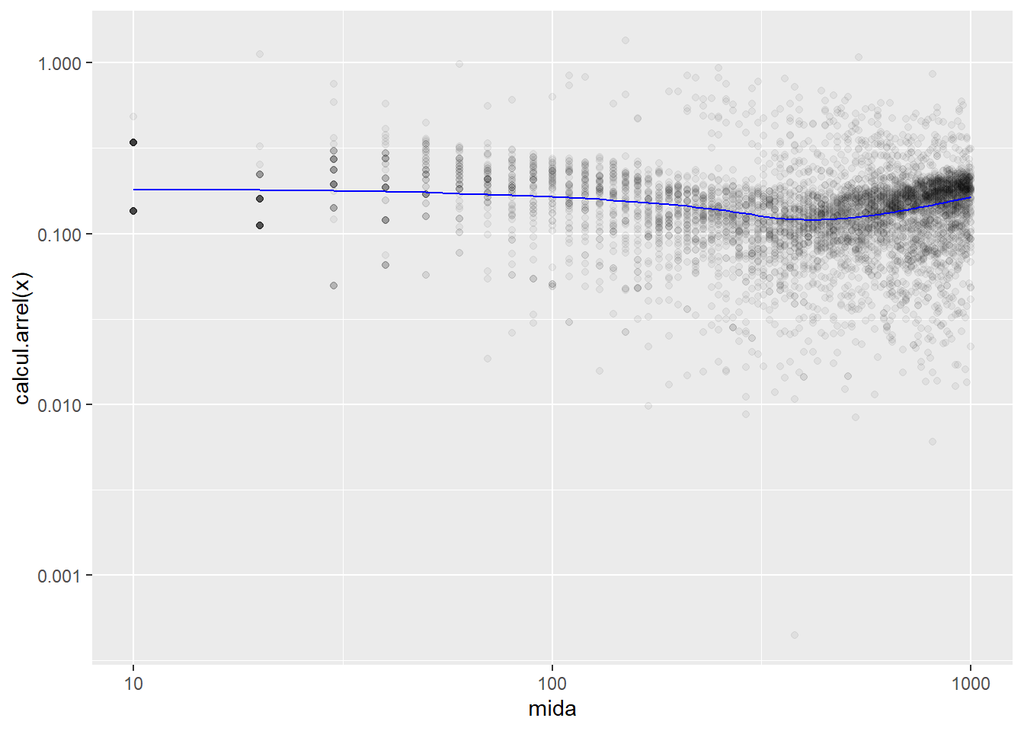

```r
veure.tendencia(residuals(mods.log$lm.bubblesort))
```

#### QuickSort *desordenat*

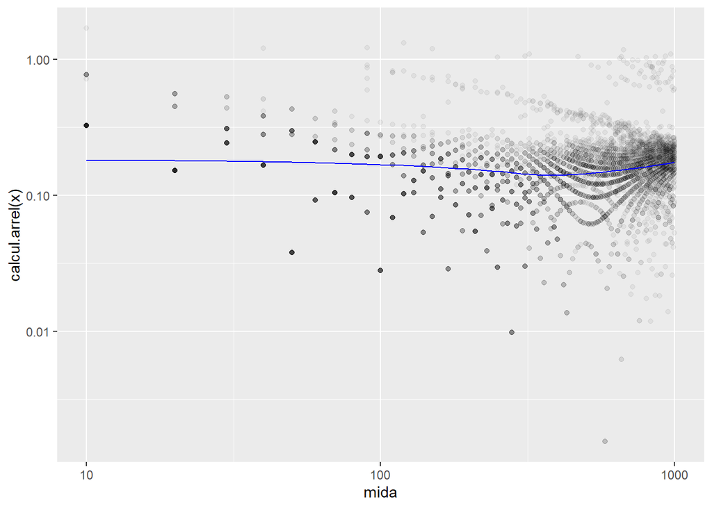

```r
veure.tendencia(residuals(mods.log$lm.quicksort))
```

#### MergeSort *desordenat*

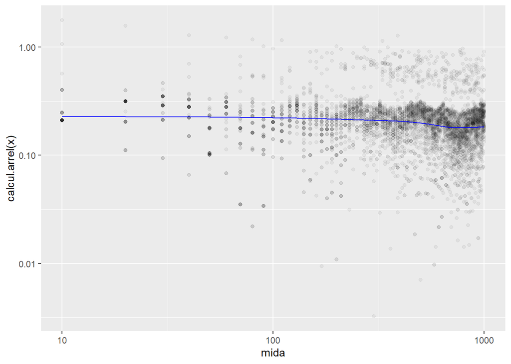

```r
veure.tendencia(residuals(mods.log$lm.mergesort))
```

Podem veure que tot i no ser homoscedastics, aplicant una transformació logarítmica estan més a prop de ser-ho.

Finalment, vam comprovar si els residus seguien una skew normal.

#### BubbleSort *desordenat*

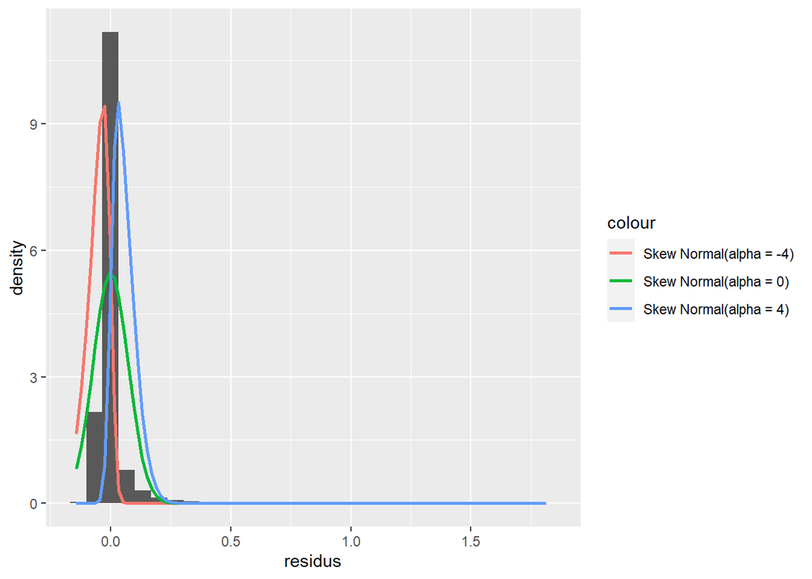

```r
histograma3(residuals(mods.log$lm.bubblesort))
```

#### QuickSort *desordenat*

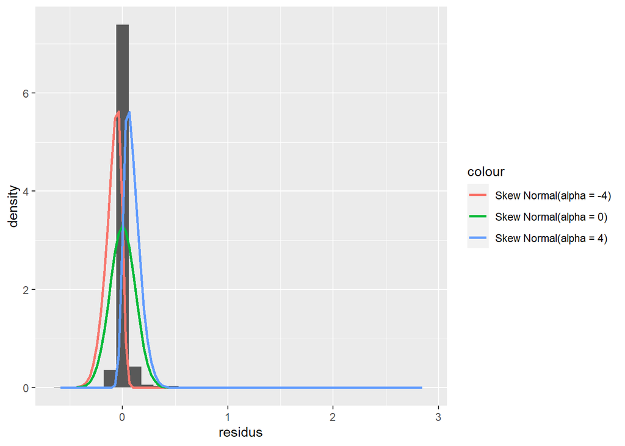

```r
histograma3(residuals(mods.log$lm.quicksort))
```

#### MergeSort *desordenat*

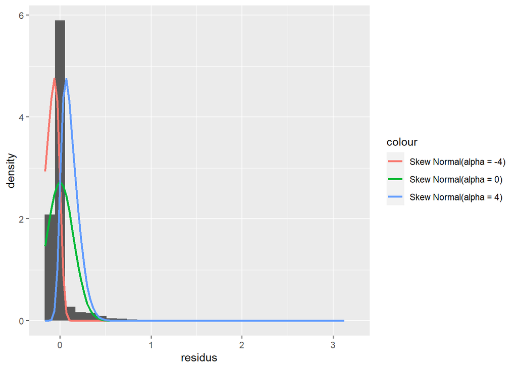

```r
histograma3(residuals(mods.log$lm.mergesort))
```

### Assumpcions seguides

Per poder construir l’interval de confiança en el que sabem que els errors intentaven seguir una normal, hem seguit l’assumpció de què, sabent ja que els residus no són normals, vam dir, pel teoriema del límit central almenys la nostra mostra és bastant gran.

```r
dim(simulacions.res)
```

```
## [1] 5000   12
```

Com que la nostra mostra és bastant gran segons el teorema, podem assumir que la mitjana de la mostra segueix una normal com, $N(\mu, \frac{\sigma}{\sqrt{n}})$.

Altres assumpcions, hem vist que no podem assumir una normal, i tot i que veient els gràfics ens pugui semblar que els residus són homoscedastics, tampoc tenim evidències per assumir l’homoscedasticitat dels residus.

### Conclusió extreta

Finalment, la conclusió final és que els residus dels temps dels diferents algoritmes estudiats segueixen la forma que han de seguir segons la teoria, p.e. bubblesort és $O(n^2)$ és el que aplicant la transformació logarítmica sembla seguir més una normal, mentre que el quicksort i el mergesort amb $O(n \cdot log(n))$ segueix més el logaritme que una normal. I quan diem que el bubblesort segueix una normal, en realitat volem dir que segueix una normal amb un biaix cap al 0, *cap a l’esquerra*.

També és interessant que treballant amb el logaritme dels temps el test d’homoscedasticitat ens porta a rebutjar la hipòtesi nul·la, però veient els gràfics, veiem que els residus no semblen seguir cap tendència.

## Qüestions futures

Com a qüestions futures, podríem relacionar aquest estudi dels algoritmes d’ordenació amb altres assignatures, com p.e.

- A **bases de dades**, vam veure que en el moment en què en un SGBD (Sistema Gestor de Bases de Dades) fem una consulta SQL, el SGBD fa una sèrie de passos: **Primer converteix la consulta amb sintaxi SQL a operacions d’Àlgebra relacional**, després **a partir d’un arbre inicial de consulta optimitza la consulta**, el **tercer pas** amb la consulta ja optimitzada és el que ens interessa, ja que en aquest pas el SGBD **mitjançant estàdistiques intenta escollir un algoritme per cada operació**, en el càs de **l’operació d’ordenació**, *order by*, el **SGBD escolliria el quicksort o el mergesort**, però **en cap cas escolliria el bubblesort**, només ho escolliria en el cas en què la taula sobre la qual es fa la consulta tingui pocs registres, però **gairebé sempre acabarà escollint el quicksort**, i **algun cop escolliria el mergesort**. La qüestió és, **quines estadístiques pot mirar el SGBD per tal d’escollir el millor algoritme per ordenar una taula** amb pocs i molts registres? Quan és millor escollir un algoritme recursiu com quicksort i mergesort, o quan és millor escollir un algoritme més senzill com bubblesort?
- A **fonaments de la computació**, acabem de veure que hi ha problemes **decidibles** (que existeix un algoritme/màquina de Turing que els resol) i **indecidibles** (que encara no s’ha trobat cap algoritme/màquina de Turing que els resolgui), els **algoritmes d’ordenació** clarament **serien dels decidibles**, però a dins d’aquest grup, està clar que formarien part de la classe de problemes que es poden resoldre en temps polinòmic (classe P). Entre els decidibles també vam veure que hi ha una classe NP (No polinòmic), on hi ha els problemes que no es poden resoldre en temps polinòmic, però sí que es pot validar si una solució és correcte en *temps polinòmic*, i també vam veure que $P \in NP$, i tot i que no s’ha demostrat encara, molts creuen que $P \neq NP$. La qüestió és, podem resoldre el problema de l’ordenació d’un vector convertint aquest problema a un problema NP-complet, com el SAT o el de la k-colorabilitat d’un graf? D’aquesta manera podríem ordenar un vector, reduïnt el problema a p.e. la k-colorabilitat d’un graf, d’aquesta manera si aconseguim pintar cada vèrtex d’un graf sense que hi hagui adjacents amb el mateix color haurem ordenat el vector. L’algoritme seria $O(2^n)$, *o pitjor, $O(n!)$*, i a partir d’aquí, podríem comparar la forma dels errors d’un algoritme d’ordenació que sigui $O(2^n)$ amb els algoritmes d’ordenació que hem estudiat?
- Tot i que potser seria més fàcil recordar l’assignatura de **Estructures de Dades i Algorítmica**, i fer servir un algoritme de backtracking per resoldre el problema de l’ordenació d’un vector, d’aquesta manera tindrem un algoritme $O(2^n)$ per comparar-ho amb els algoritmes d’ordenació de $O(n^2)$ o $O(n \cdot log(n))$ que acabem d’estudiar, i per comparar també la forma dels errors.

Una altre qüestió que ens podríem plantejar, és si el llenguatge escollit per implementar els algoritmes afecta molt o poc a la forma dels errors, nosaltres l’hem provat amb c++, però també ho podríem haver provat amb c, java, R, etc … Per fer això només hauríem de modificar el conjunt de dades `algoritmes` com.

```r
algoritmes2 = mutate(algoritmes,
                     llenguatge = "c++")
algoritmes2
```

```
## # A tibble: 3 × 4
##   algoritme  estable implementacio.recursiva llenguatge
##   <chr>      <lgl>   <lgl>                   <chr>
## 1 bubblesort TRUE    FALSE                   c++
## 2 quicksort  FALSE   TRUE                    c++
## 3 mergesort  TRUE    TRUE                    c++
```

També podríem executar cada algoritme amb un llenguatge d’alt nivell com c++ o java, i amb un llenguatge que estigui a més baix nivell, és a dir, fent servir el llenguatge c mitjançant crides al sistema, i veure si aixó té efecte en la forma dels errors i en la velocitat dels algoritmes.

## Material addicional

- Apunts d’Estadística.
- Apunts de Bases de dades.
- Apunts de Fonaments de la Computació.

## Llista de tasques

*Opcional, si us va bé anar indicant les feines que cal fer i com les penseu repartir entre els membres de l’equip.*